# Geospatial Analysis with R

Class 5

Lyndon Estes & Zhiwen Zhu

9/6/2017

# Overview

- A review of concepts/skills we have learned so far.
  - The essential
  - The important to know
  - The good to know because it might help, now or down the track
- Skills for the next assignment
  - Branching
  - Working with the apply family, data.frames
- Potential projects

# Concepts/skills

- R objects
- R environments

# R objects:

- Essential:
  - Main object types:
    - Data
      - Data types:
      - Data structures
    - Functions
      - Varying complexity, from `(`, `+`, `-`, to `lm`
    - Results
      - Output objects of varying complexity: vector, data.frame, list (S3), S4
  - Objects versus functions:

    “Everything that exists is an object. Everything that happens is a function call” (John Chambers, quoted by [Wickham](http://adv-r.had.co.nz/Functions.html#all-calls))
- Important:
  - More on concept of **object-oriented programming**, from [Advanced R](http://adv-r.had.co.nz/S3.html):

    “Central to any object-oriented system are the concepts of class and method. A class defines a type of object, describing what properties it possesses, how it behaves, and how it relates to other types of objects. Every object must be an instance of some class. A method is a function associated with a particular type of object.”

    “While computations are still carried out via methods, a special type of function called a generic function decides which method to call.” **[This is what Method Dispatch means]**

    “The primary use of OO programming in R is for print, summary and plot methods.”
  - Try this on your machines

```r
methods(plot)
```

```
- S3 and S4 are the two main OO systems used by R
- The primary spatial packages that we will use in R use S4
```

- Good to know
  - How generic functions are created
  - Precise differences between S3 and S4
    - S4 has fairly different structure
    - Sometimes you will want to get stuff out of an S4 object
    - Getting stuff out of an S4 object can be tricky

# R environments

Different spaces where objects exist and functions happen

### Essential

1. Environment hierarchy (from most ancestral to least)

```
- empty
- base
- package1
    - package1::fun1
- package2
    - package2::fun2
- package3 (e.g. one you created)
    - package3::fun3 (package environment)
    - package3:::unexportedfunction (namespace environment)
- Global environment
    - exported functions from loaded packages
        - fun1
        - fun2
        - fun3
    - objects you created
        - data object
        - function you created outside of package
        - summary
```

2. This hierarchy defines the search path:

Run this to see the hierarchy of your enviroments

```r
search()
```

Run this to see the environment that encloses (i.e. the namespace) a given function

```r
f <- function() 1
environment(f)  # global
environment(sum)  # a primitive, written in C, no R code, no env
environment(lm)  # stats
environment(summary)  # an exported generic
```

Recall and run this example, after first installing `raster` and `Hmisc`

```r
# uncomment and run if you need to
# install.packages(c("Hmisc", "raster"))
library(raster)
library(Hmisc)
mask
search()
detach("package:raster", unload=TRUE)
detach("package:Hmisc", unload=TRUE)
library(Hmisc)
library(raster)
mask
```

3. Where packages live:

When you are building them, versus when they are installed.

### Important/Good to Know

# New skills

### Git branching

To create a new branch in your git repo, in shell (best to open from Rstudio)

Creates the new branch and switches you in to it

```
git checkout -b newbranchname
```

Commit your new branch to GitHub

```
git push origin newbranchname
```

To switch into an existing branch

```
git checkout somebranchname
```

# New skills

### (Pseudo) Random number generation

You will end up generating random data for many purposes, so here are a few ways to do that.

- Random integers

```r
a <- sample(x = 1:20, size = 30, replace = TRUE)
a
```

```
##  [1] 18  5 16 12  7 14  7  5 19  1 20  7 14 11 17  4  8  4  6 13  7  9 15
## [24] 14  7 10  6  4  8 19
```

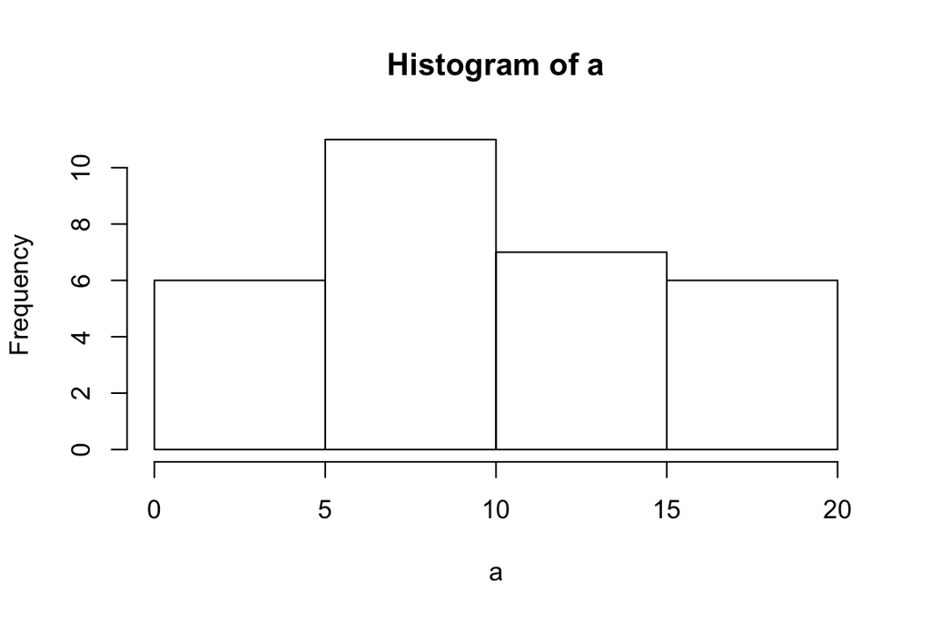

```r
hist(a)
```

- Random number from a uniform distribution

```r
b <- runif(n = 30, min = 10, max = 20)
b
```

```
##  [1] 13.94048 17.79881 12.84159 18.53721 11.72242 10.79264 12.92065
##  [8] 18.40371 19.45268 10.44965 17.58383 12.96888 16.51054 10.84990
## [15] 19.75481 10.13625 15.38869 19.65782 11.01073 12.56751 18.95147
## [22] 13.87944 17.94285 13.49397 11.38744 16.50509 15.44004 19.45244
## [29] 15.71746 19.53634
```

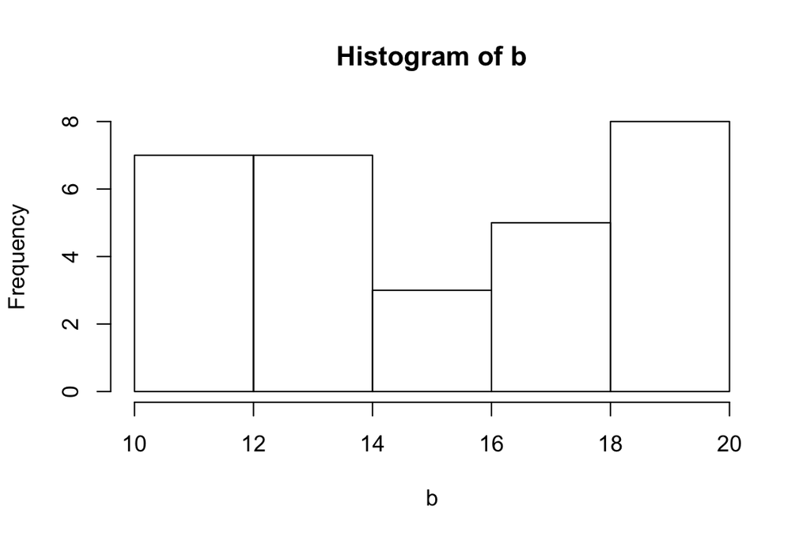

```r
hist(b)
```

- Random number from a normal distribution

```r
d <- rnorm(n = 30, mean = 15, sd = 2)
d
```

```
##  [1] 16.54610 16.96531 16.34018 12.15851 14.52785 13.05043 13.32783
##  [8] 13.15501 12.75307 15.74457 18.82147 16.82399 13.36281 13.59105
## [15] 15.12165 15.88472 11.85035 10.52378 13.38504 18.04108 14.92898
## [22] 17.10780 14.87889 16.90638 14.17345 15.14465 13.70502 13.42846
## [29] 14.86977 13.96106
```

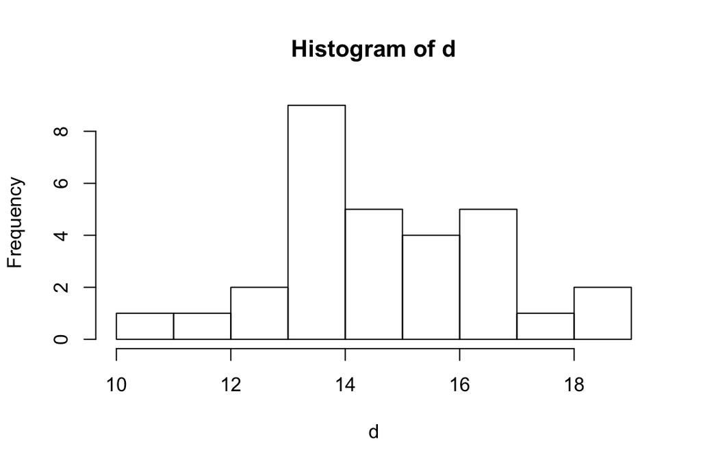

```r
hist(d)
```

- Make sure you get the same random numbers every time

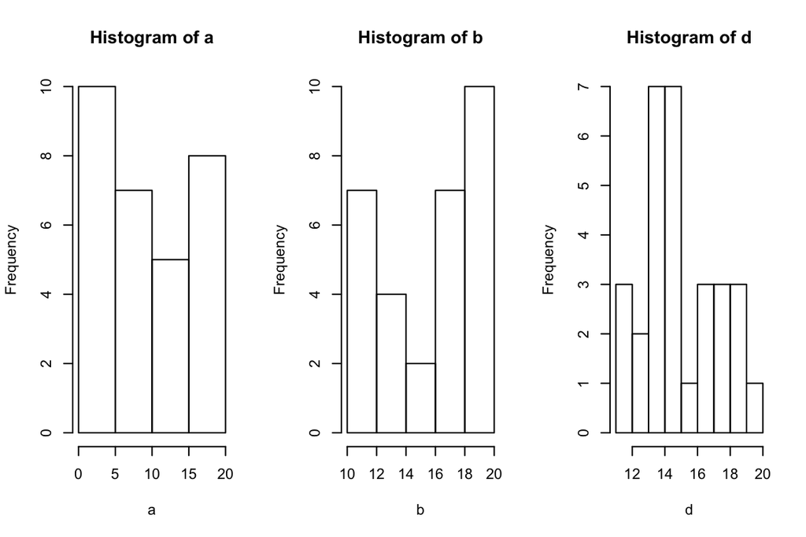

```r
set.seed(2)
a <- sample(x = 1:20, size = 30, replace = TRUE)
b <- runif(n = 30, min = 10, max = 20)
d <- rnorm(n = 30, mean = 15, sd = 2)
par(mfrow = c(1, 3))
hist(a)
hist(b)
hist(d)
```

- Try repeating this, using different seed values, and also running the code as a block, or stepping through it line by line.

# New Skills

### Indexing

To extract subsets from different types of data structures

- With numeric index values

```r
# Vectors
a <- 1:10
a[10]  # 10th values of A
```

```
## [1] 10
```

```r
a[c(1, 3)]  # 1st and 3rd values in A
```

```
## [1] 1 3
```

```r
# matrices
mat <- cbind(a = 1:10, b = 1:10, c = 1:10)
mat[1, 1]  # row 1, column 1
```

```
## a
## 1
```

```r
mat[, 3]  # all of column 3
```

```
##  [1]  1  2  3  4  5  6  7  8  9 10
```

```r
mat[2, ]  # all of row 2
```

```
## a b c
## 2 2 2
```

```r
# data.frames
d <- c(rep("pigs", 3), rep("ponies", 4), rep("puppies", 3))
dat <- cbind.data.frame(mat, d)
dat[1, 1]  # row 1, column 1
```

```
## [1] 1
```

```r
dat[, 3]  # all of column 3
```

```
##  [1]  1  2  3  4  5  6  7  8  9 10
```

```r
dat[2, ]  # all of row 2
```

```
##   a b c    d
## 2 2 2 2 pigs
```

```r
dat[2:4, 3:4]  # rows 2:4 in columns 3:4
```

```
##   c      d
## 2 2   pigs
## 3 3   pigs
## 4 4 ponies
```

```r
dat[2:4, c(2, 4)]  # rows 2:4 in columns 2 and 4
```

```
##   b      d
## 2 2   pigs
## 3 3   pigs
## 4 4 ponies
```

```r
# lists
l <- list(a, mat, dat)
names(l) <- c("a", "mat", "dat")  # give the list names
l[[1]]  # first element (a)
```

```
##  [1]  1  2  3  4  5  6  7  8  9 10
```

```r
l[[3]]  # third element (dat)
```

```
##     a  b  c       d
## 1   1  1  1    pigs
## 2   2  2  2    pigs
## 3   3  3  3    pigs
## 4   4  4  4  ponies
## 5   5  5  5  ponies
## 6   6  6  6  ponies
## 7   7  7  7  ponies
## 8   8  8  8 puppies
## 9   9  9  9 puppies
## 10 10 10 10 puppies
```

```r
l[[3]][2:4, c(2, 4)]  # rows 2:4 in col 2 & 4 in 3rd element
```

```
##   b      d
## 2 2   pigs
## 3 3   pigs
## 4 4 ponies
```

- By name

```r
names(a) <- letters[1:length(a)]
a["f"]

mat[1, "a"]
mat[, "b"]

dat[1, "d"]
dat[, "c"]

l$a
l$mat
l$dat[2:4, c("b", "d")]
```

- Matching

```r
dat[dat$d == "pigs", ]  # all rows of dat where d == "pigs"
dat[dat$d == "pigs", 1]  # all values from a where d == "pigs"
dat[dat$d == "pigs", "a"]  # all values from a where d == "pigs"

# another way
dat[dat[, 4] == "pigs", ]  # all rows of dat where d == "pigs"
dat[dat[, 4] == "pigs", 1]  # all values from a where d == "pigs"
dat[dat[, 4] == "pigs", "a"]  # all values from a where d == "pigs"
```

# New skills

### Control structures

Very important, particularly the apply family of functions

- First, `for` loops, which occur in all languages

```r
for(i in 1:10) {
  print(dat[i, "a"] * 10)
}  # Where are the results kept?

a <- rep(NA, 10)
for(i in 1:10) {
  a[i] <- dat[i, "a"] * 10
}  # Where are the results kept?
a
```

- The output of `for` has to be “caught” in an object you define
- One reason we use the `*apply` family is because it is designed to put results into an object
  - `apply` applies a function to the rows or columns of a data.frame or matrix

```r
aa <- apply(dat[, 1:3], 1, sum)  # sum across columns
aa
bb <- apply(dat[, 1:3], 2, sum)  # sum across rows
bb
```

```
In the example above, why did I only take the first 3 columns of dat?

- `sapply` operates on a list, or using an index of your choosing, and produces an output vector or data.frame
```

```r
cc <- sapply(l, function(x) sum(x[1:2]))
cc
dd <- sapply(1:10, function(x) sum(dat[x, 1:3]))
dd
```

```
- `lapply` also operates on a list, or applies a function to an index of your choosing, but returns a list
```

```r
ee <- lapply(l, function(x) sum(x[1:2]))
ee
ff <- lapply(1:10, function(x) sum(dat[x, 1:3]))
ff
```

```
- In general, if you want to keep the output of your iterative operation, best look to `*apply`. If not, `for` loops can be useful
```